# Assignment 9

Karen Clark

July 20, 2016

# Questions for Each Dataset:

Dataset = hsales

## Plot the time series. Can you Indentify seasonal fluctuations and/or a trend?

```r
#first load the fpp package to obtain the dataset
library(fpp)
```

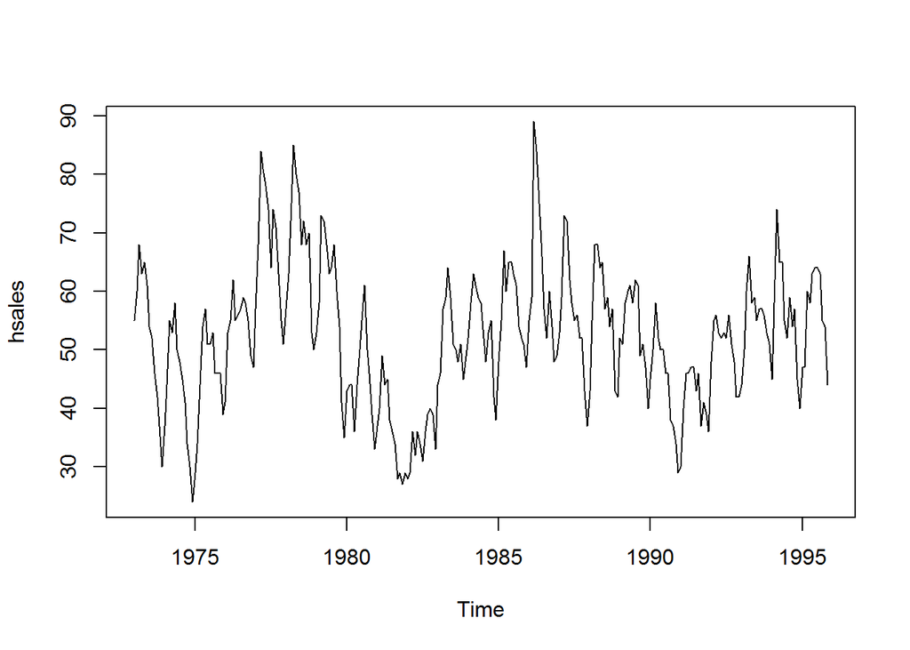

```r
#load data into R
data("hsales")

#Time series plot
plot(hsales)
```

The data shows strong seasonality within each year. There is no apparant trend in the data.

## Use a classical decomposition to calculate the trend-cycle and seasonal indices.

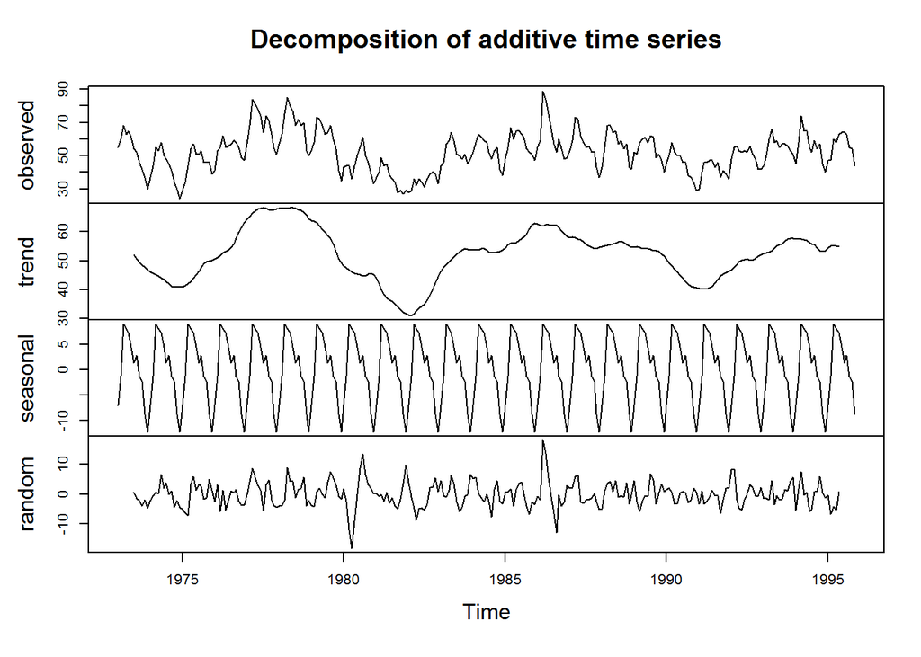

```r
#decomposition of hsales
 hsalesd <- decompose(hsales)

#trend-cycle plot from decomposition
plot(hsalesd)
```

## Do the results support the graphical interpretation of part (a)?

Based on the seasonal trend plot - yes. The seasonal plot again displays the yearly seasonality.

## Compute and plot the seasonally adjusted data

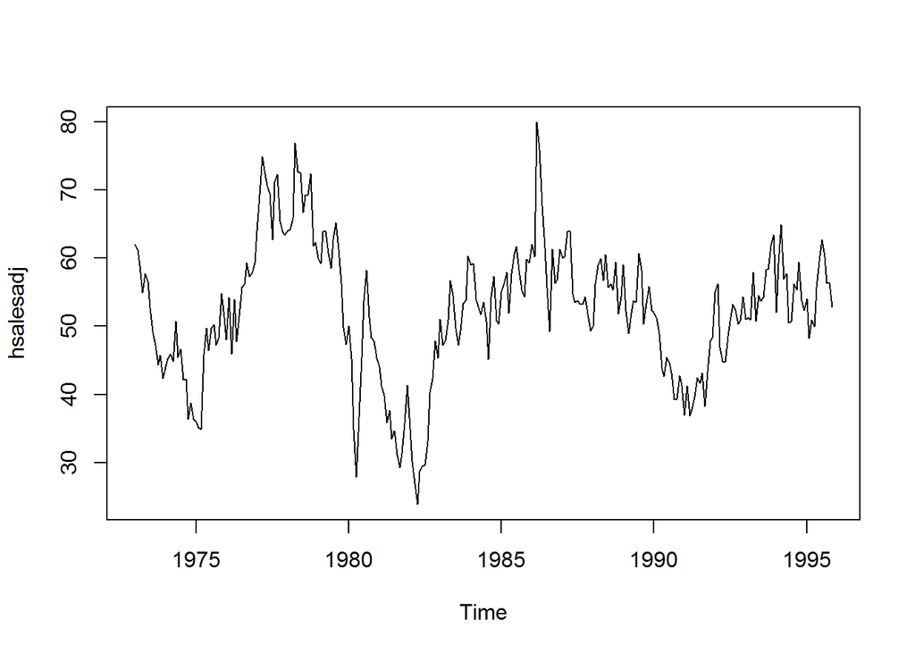

```r
#store the seasonal information for the dataset in the
hsalesadj <- seasadj(hsalesd)

#plot seasonally adjusted data
plot(hsalesadj)
```

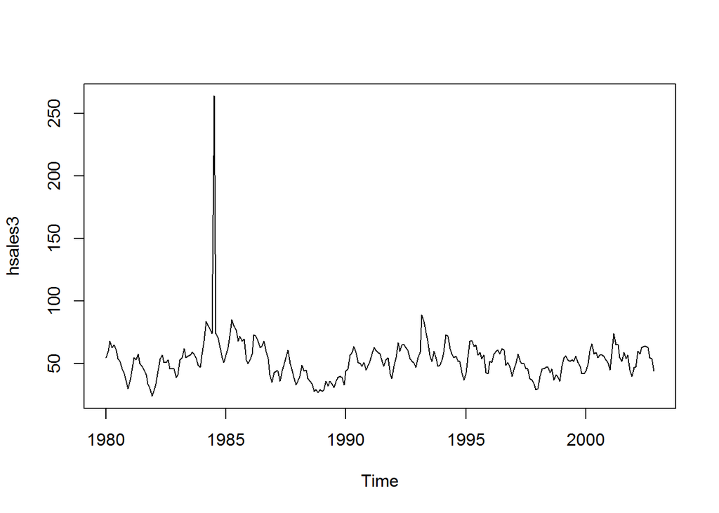

```r
#create an outlier
hsales3 <- ts(c(hsales[1:54],hsales[55]+200,hsales[56:275]),start=c(1980,1),frequency=12)

#plot data
plot(hsales3)
```

## Does it make a difference if the outlier is near the end rather than in the middle of the time series?

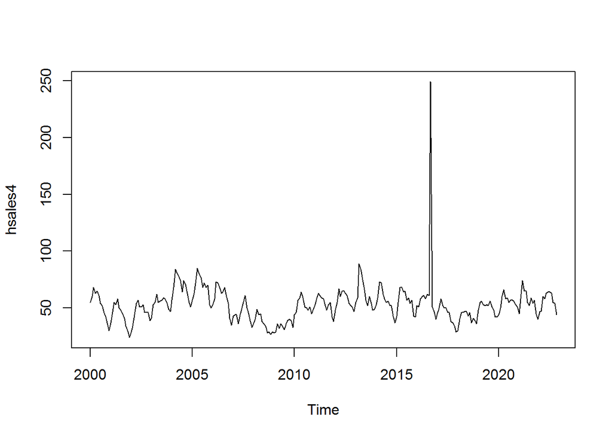

```r
#move the outlier toward the end of the timeseries
hsales4 <- ts(c(hsales[1:200],hsales[201]+200,hsales[202:275]),start=c(2000,1),frequency=12)

#plot the outlier
plot(hsales4)
```

The only difference with the outlier at the end is the large spike in sales moves to that year. The rest of the sales data follows the same pattern.

## Use STL to decompose the series

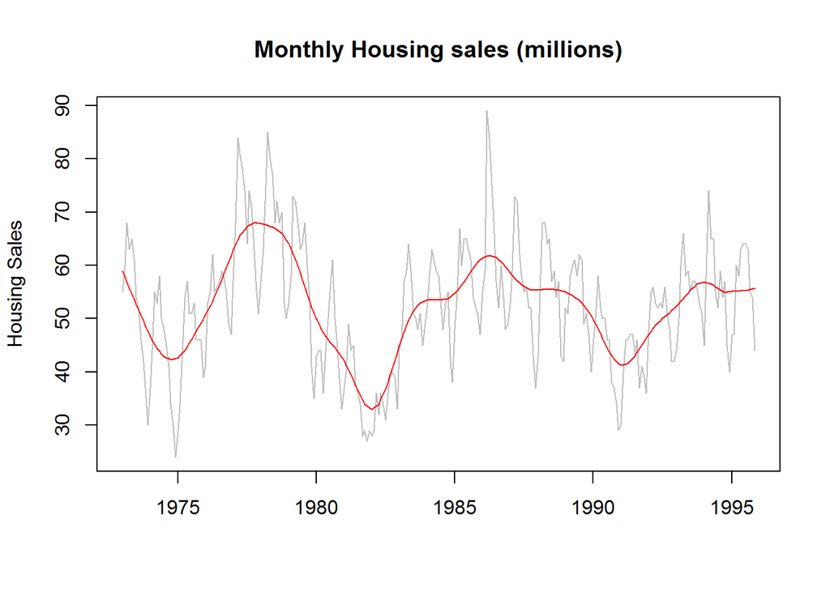

```r
#decompose data with stL function
hsalesfit <- stl(hsales, s.window = 5)

#plot data

plot(hsales, col="gray",
  main="Monthly Housing sales (millions)",
  ylab="Housing Sales", xlab="")
lines(hsalesfit$time.series[,2],col="red",ylab="Trend")
```

#volatility Assignment

S&P Stock Assigned:AG10

```r
#load library for tseries package
library(tseries)

#Get data for AG10 stock
 SNPdata <- get.hist.quote(instrument = "agio",quote="Close", provider = "yahoo")
```

```
## time series starts 2013-07-24
```

## Calculate Log Returns

```r
#Calculate log returns for data
SNPret <- log(lag(SNPdata)) - log(SNPdata)

#Display Log Data
SNPret
```

```
##                    Close
## 2013-07-24 -0.1186625743
## 2013-07-25  0.0266398270
## 2013-07-26  0.0038481069
## 2013-07-29  0.0159338670
## 2013-07-30  0.0020597330
## 2013-07-31 -0.0003429943
## 2013-08-01 -0.0106916004
## 2013-08-02 -0.0013879600
## 2013-08-05  0.0055401806
## 2013-08-06  0.0242209013
## 2013-08-07  0.0060484055
## 2013-08-08  0.0050125418
## 2013-08-09  0.0158733492
## 2013-08-12  0.0287813233
## 2013-08-13  0.0436614086
## 2013-08-14 -0.0181683211
## 2013-08-15 -0.0084257013
## 2013-08-16 -0.0918376482
## 2013-08-19 -0.0841735568
## 2013-08-20 -0.0764678489
## 2013-08-21  0.0270608633
## 2013-08-22  0.0155827851
## 2013-08-23 -0.0104916834
## 2013-08-26 -0.1224324996
## 2013-08-27  0.0196727656
## 2013-08-28  0.0738296805
## 2013-08-29 -0.0532634029
## 2013-08-30  0.0000000000
## 2013-09-03  0.0759238827
## 2013-09-04  0.0632109501
## 2013-09-05 -0.0007382798
## 2013-09-06 -0.0107667272
## 2013-09-09  0.0341254174
## 2013-09-10 -0.0215140484
## 2013-09-11 -0.0073991830
## 2013-09-12 -0.0142111968
## 2013-09-13  0.0130965766
## 2013-09-16 -0.0313410587
## 2013-09-17  0.0394862720
```

[output cut: 698 more lines]

```
## 2016-06-27  0.0860797061
## 2016-06-28  0.0160473333
## 2016-06-29 -0.0624479395
## 2016-06-30  0.0205510476
## 2016-07-01 -0.0308666239
## 2016-07-05  0.0369272252
## 2016-07-06 -0.0093392694
## 2016-07-07  0.0028109411
## 2016-07-08 -0.0058651195
## 2016-07-11  0.0358212538
## 2016-07-12 -0.0739507977
## 2016-07-13  0.0073063891
## 2016-07-14  0.0127790285
## 2016-07-15 -0.0007190653
## 2016-07-18 -0.0403625290
```

## Calculate volatility measure

```r
#Calculate volatility
SNPvol <- sd(SNPret) * sqrt(250) * 100

#Display Volatility
SNPvol
```

```
## [1] 81.30567
```

The volatility of the AGIO stock is 81%. Which indicates the stock returns vary greatly from year to year.

## Calculate volatility measure with a continuous lookback window

```r
#Volatility function
get
```

[output not shown]

```r
Vol <- function(d, logrets)
{

    var = 0

    lam = 0

    varlist <- c()

    for (r in logrets) {

        lam = lam*(1 - 1/d) + 1

    var = (1 - 1/lam)*var + (1/lam)*r^2

        varlist <- c(varlist, var)

    }

    sqrt(varlist)
}
```

# Plot results

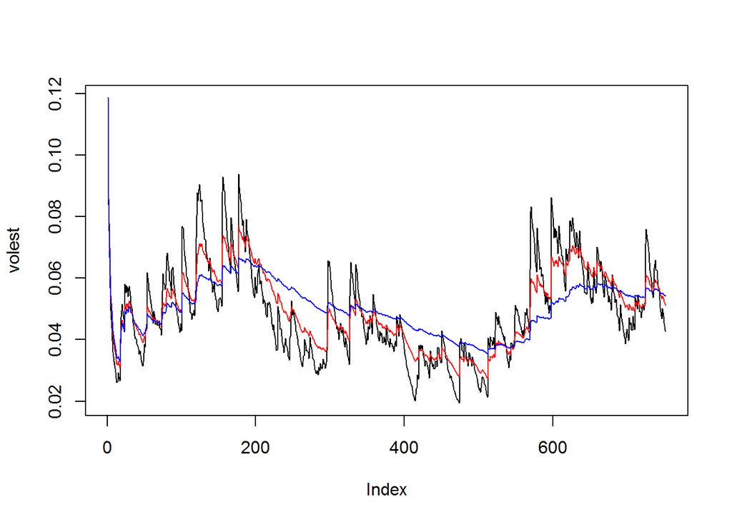

```r
volest <- Vol(10,SNPret)

volest2 <- Vol(30,SNPret)

volest3 <- Vol(100,SNPret)

plot(volest,type="l")

lines(volest2,type="l",col="red")

lines(volest3, type = "l", col="blue")
```